# Red Wine Exploratory Data Analysis by Sanyam Chaudhary

```
##  [1] "Index"                "fixed.acidity"        "volatile.acidity"
##  [4] "citric.acid"          "residual.sugar"       "chlorides"
##  [7] "free.sulfur.dioxide"  "total.sulfur.dioxide" "density"
## [10] "pH"                   "sulphates"            "alcohol"
## [13] "quality"
```

# Univariate Plots Section

Distribution of a feature is demonstrated by histogram, boxplot and the summary stat function.

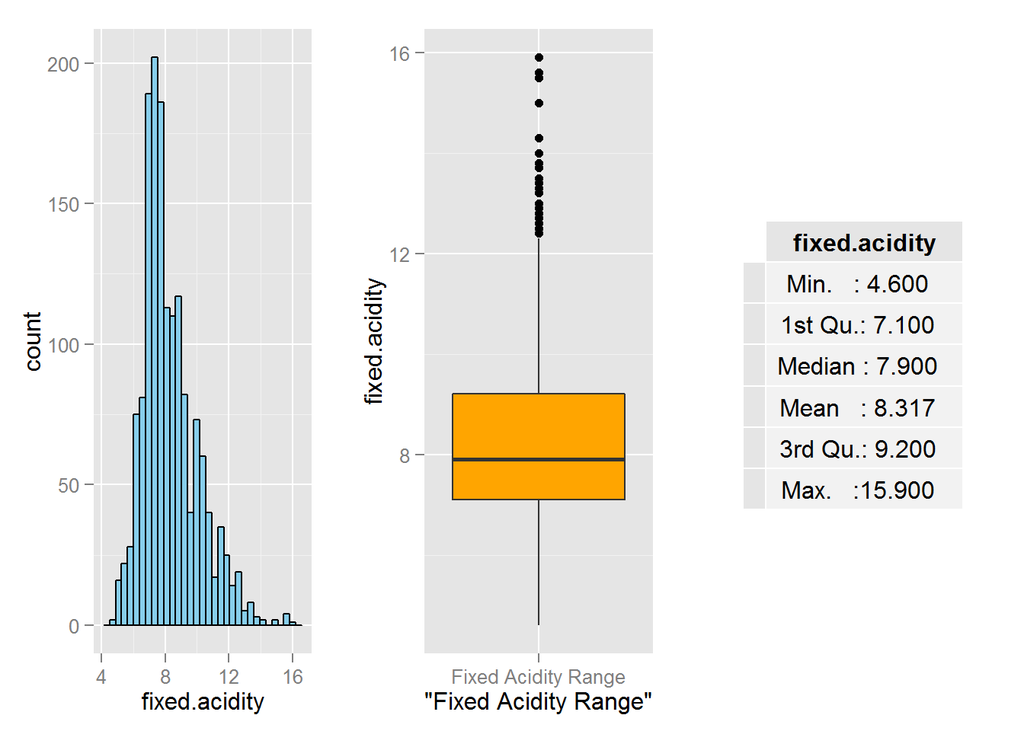

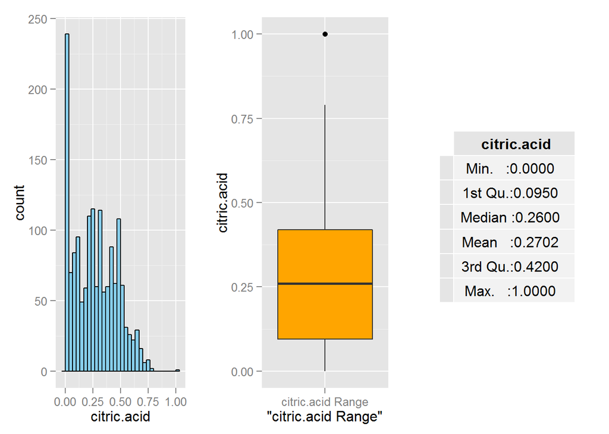

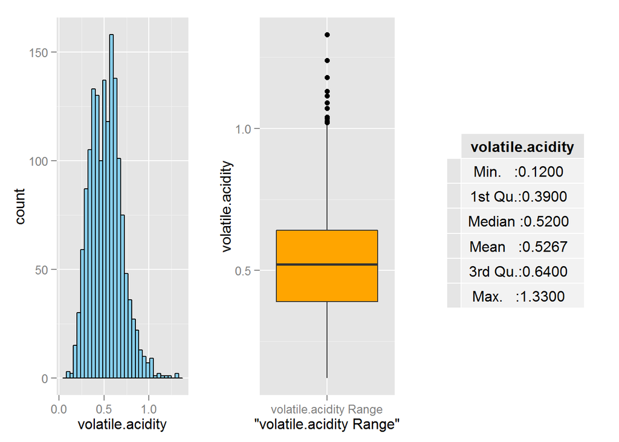

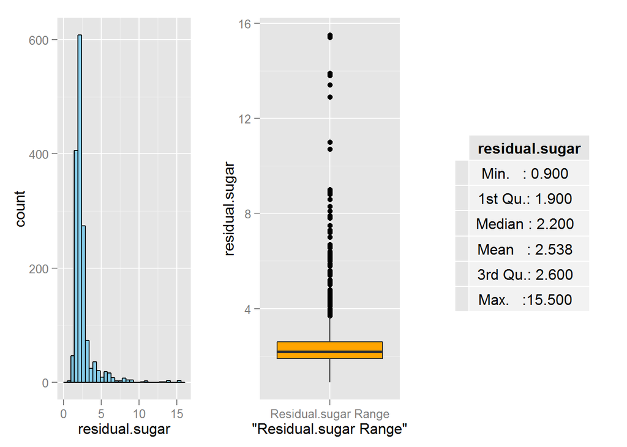

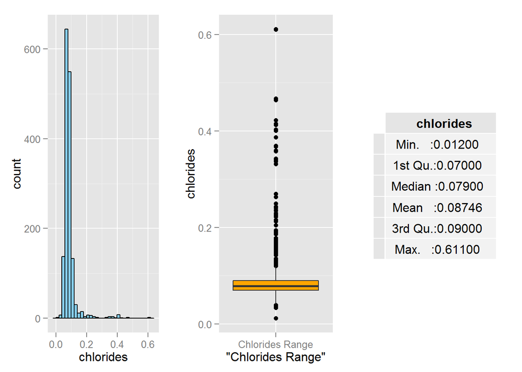

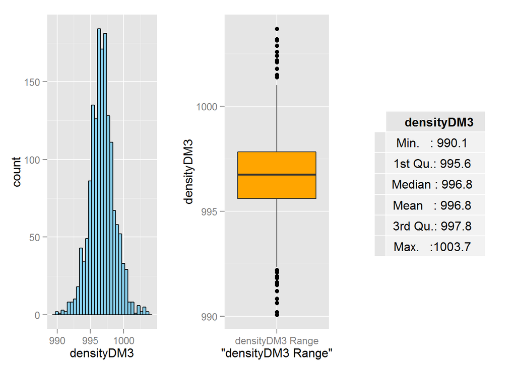

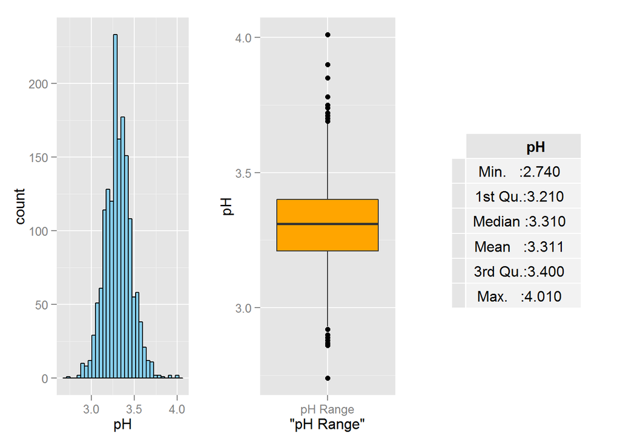

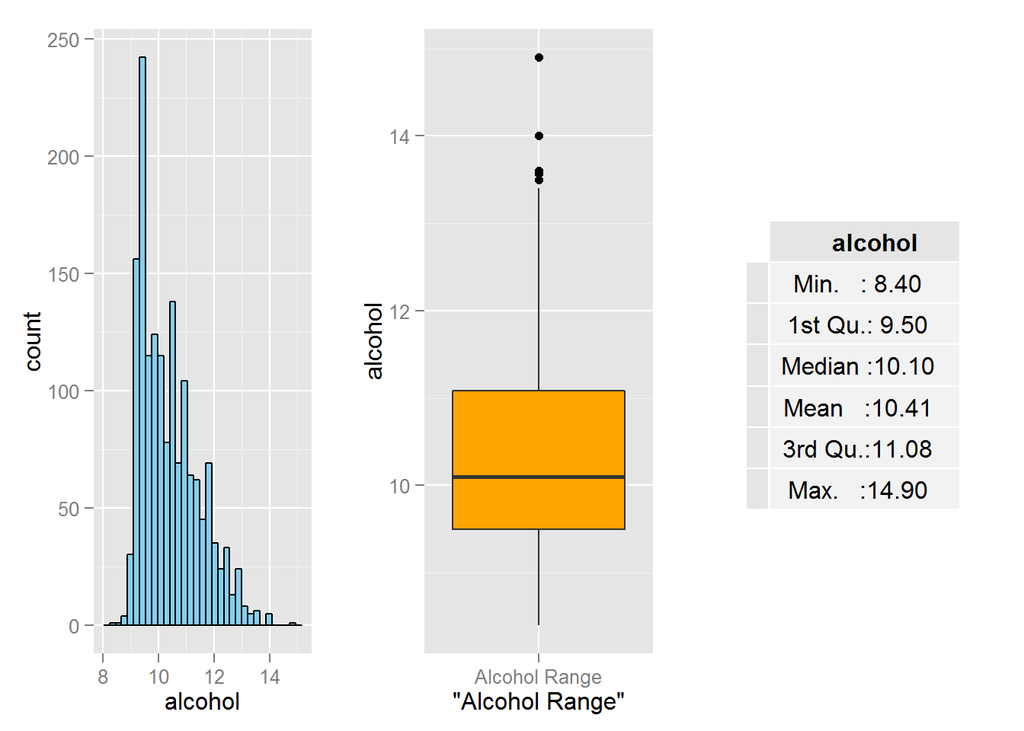

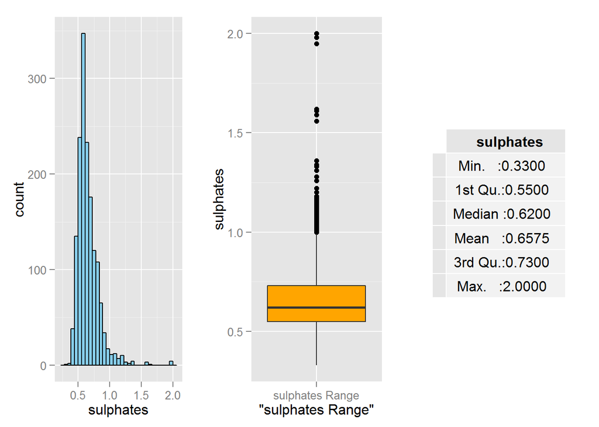

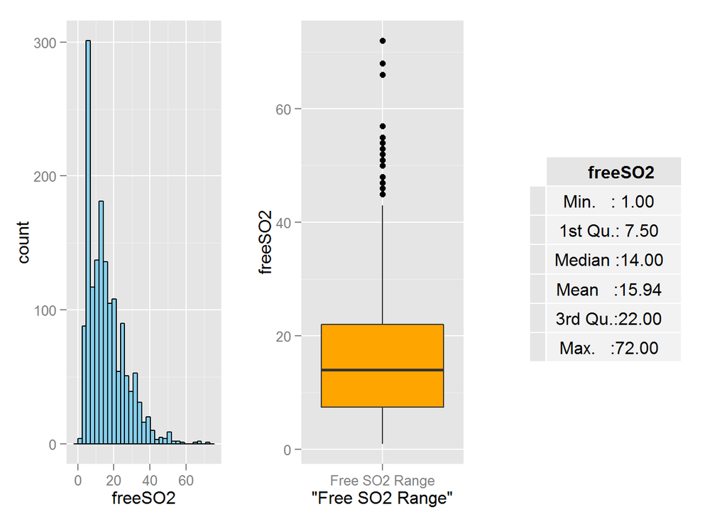

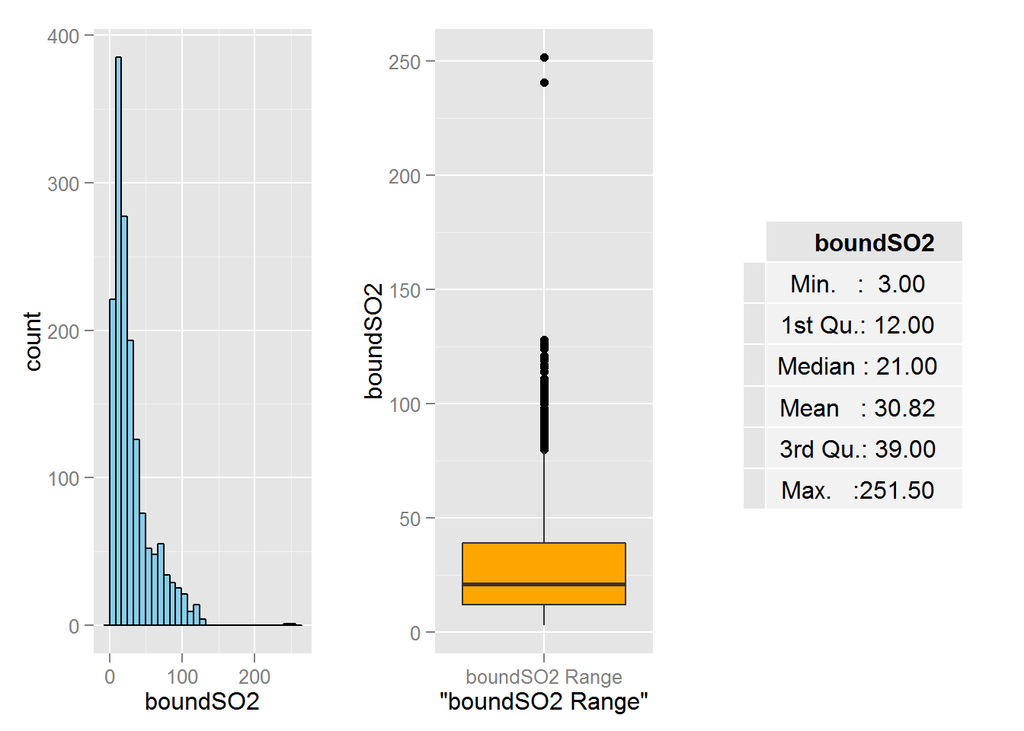

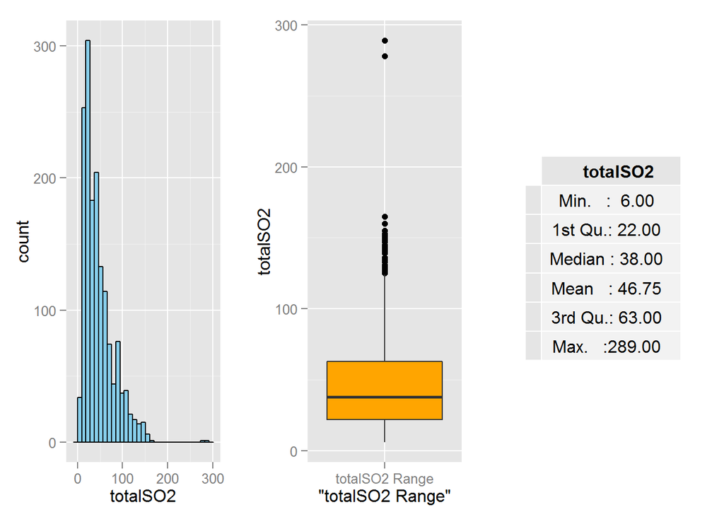

[1 more figures not shown]

# Univariate Analysis

### What is the structure of your dataset?

Data set has 1599 observations with 13 variables. Out of those 13, 1 is index, 11 are physiocochemical variables and 1 quality is treated as main variable for this analysis.

### What is/are the main feature(s) of interest in your dataset?

Main feature for this dataset is quality. Effectively, I want to see from this data set that is there a relationship between quality and other variables and can we build a model to predict the quality of wine? Based on the lecture notes from class any correlation between 2 variables >.6 is strong and >.3 is meaningful, So I am going to keep an eye out for variables with that correlation.

### What other features in the dataset do you think will help support your investigation into your feature(s) of interest?

Based on the description of variables names, I am tempted to see the relation between alcohol, citric acid and other variables which are mentioned to downgrade or upgrade the quality of wine.

### Did you create any new variables from existing variables in the dataset?

Yes, I created a factored quality Variable. Also calculated Bound SO2 after looking at the variable description for Total SO2.

### Of the features you investigated, were there any unusual distributions? Did you perform any operations on the data to tidy, adjust, or change the form of the data? If so, why did you do this?

Yes, I saw that distribution of quality variable is uneven, so much so that quality with level 3 and 8 have significantly low numbers. Since it is way smaller than mean of quality distribution per level, I have decided to remove level 3 and 8. I also calculated DensityDM i.e. multiply the existing Density *1000 to convert it into gm/dm^3 . I plan to plot it with residual sugar , which is expressed in gm/dm^3.

# Bivariate Plots Section

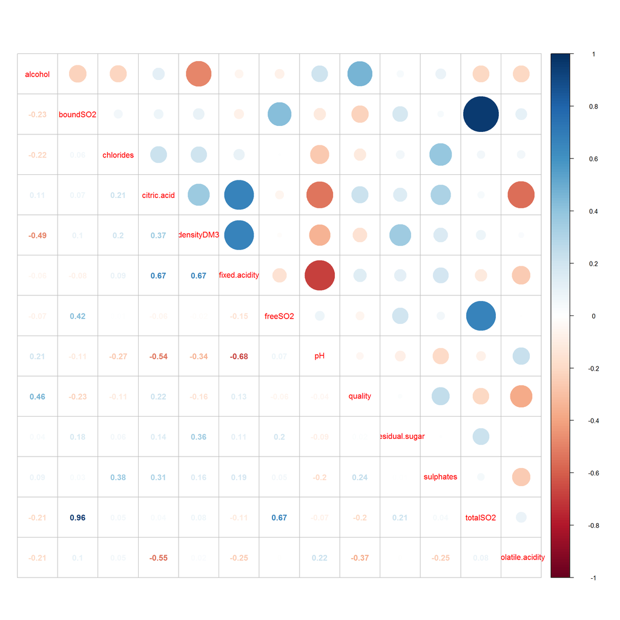

# Bivariate Analysis

### Talk about some of the relationships you observed in this part of the investigation. How did the feature(s) of interest vary with other features in the dataset?

### Did you observe any interesting relationships between the other features (not the main feature(s) of interest)?

### What was the strongest relationship you found?

# Multivariate Plots Section

# Multivariate Analysis

### Talk about some of the relationships you observed in this part of the investigation. Were there features that strengthened each other in terms of looking at your feature(s) of interest?

### Were there any interesting or surprising interactions between features?

### OPTIONAL: Did you create any models with your dataset? Discuss the strengths and limitations of your model.

# Final Plots and Summary

### Description Three

# Reflection